# **Two-Way ANOVA**

**STA4173: Biostatistics**  
Spring 2025

## Introduction: Two-Way ANOVA

- Recall that ANOVA allows us to compare the means of three or more groups.
- In one-way ANOVA, we are only considering one factor (grouping variable).
- Now, we will discuss two-way ANOVA, which allows us to consider a second factor (grouping variable).
- We now partition the SS<sub>Trt</sub> into the different factors under consideration.
- Recall that SS<sub>E</sub> is the “catch all” for unexplained variance.
  - When we add factors to our model, we are moving part of the SS<sub>E</sub> into the SS<sub>Trt</sub>.

## Introduction: Two-Way ANOVA

- Let’s discuss some of the language used in two-way ANOVA.
- Factor A has $a$ levels.
  - Smoking status: non-smoker and smoker
- Factor B has $b$ levels.
  - Hypertension: normotensive and hypertensive
- There are $ab$ treatment groups.
  - Non-smoker, normotensive
  - Non-smoker, hypertensive
  - Smoker, normotensive
  - Smoker, hypertensive

## Introduction: Two-Way ANOVA

- Now that we are including two factors, we must consider the interaction between the two.
  - *Interaction*: The relationship between [outcome] and [factor 1] depends on the level of [factor 2].
- In our example, suppose we are looking at weight as the outcome. If an interaction is detected,
  - the relationship between weight and hypertension status depends on smoking status, OR
  - the relationship between weight and smoking status depends on hypertension status.

## Introduction: Two-Way ANOVA

- The ANOVA table that we are working to construct:

| **Source** | **Sum of Squares** | **df** | **Mean Square** | *F* |
| --- | --- | --- | --- | --- |
| A | SS<sub>A</sub> | df<sub>A</sub> | MS<sub>A</sub> | *F*<sub>A</sub> |
| B | SS<sub>B</sub> | df<sub>B</sub> | MS<sub>B</sub> | *F*<sub>B</sub> |
| AB | SS<sub>AB</sub> | df<sub>AB</sub> | MS<sub>AB</sub> | *F*<sub>AB</sub> |
| Error | SS<sub>E</sub> | df<sub>E</sub> | MS<sub>E</sub> |  |
| Total | SS<sub>Tot</sub> | df<sub>Tot</sub> |  |  |

## Computation

- Let there be $a$ levels of factor A and $b$ levels of factor B.
  - $y_{ijk}$ is the observation on the $k^{th}$ experimental unit receiving the $i^{th}$ level of factor A and the $j^{th}$ level of factor B
  - $y_{i.}$ is the sum for all observations at the $i^{th}$ level of factor A,
  - $y_{.j}$ is the sum for all observations at the $j^{th}$ level of factor B,
  - $y_{ij}$ is the sum for observations at the $i^{th}$ level of factor A and the $j^{th}$ level of factor B,
  - $y_{..}$ is the sum of all observations,
  - $(y^2)_{..}$ is the sum of the squared observations,
  - $n$ is the number in each group (of $a \times b$ treatments)

## Computation

- To find the SS and df:
  $$\begin{align*}
  \text{SS}_{\text{A}} &= \frac{\sum_i y_{i.}^2}{bn} - \frac{(y_{..})^2}{abn} & \text{df}_{\text{A}} &= a-1 \\
  \text{SS}_{\text{B}} &= \frac{\sum_j y_{.j}^2}{an} - \frac{(y_{..})^2}{abn} & \text{df}_{\text{B}} &= b-1 \\
  \text{SS}_{\text{AB}}&= \frac{\sum_{ij} y_{ij}^2}{n} - \frac{(y_{..})^2}{abn} - \text{SS}_{\text{A}} - \text{SS}_{\text{B}} & \text{df}_{\text{AB}} &= (a-1)(b-1) \\
  \text{SS}_{\text{E}} &= \text{SS}_{\text{Tot}} - \text{SS}_{\text{A}} - \text{SS}_{\text{B}} - \text{SS}_{\text{AB}} & \text{df}_{\text{E}} &= ab(n-1) \\
  \text{SS}_{\text{Tot}} &= (y^2)_{..} - \frac{(y_{..})^2}{abn} & \text{df}_{\text{Tot}} &= abn-1
  \end{align*}$$

## Computation

- To find the MS:

$$\text{MS}_{\text{X}} = \frac{\text{SS}_{\text{X}}}{\text{df}_{\text{X}}}$$

- To find the test statistic:

$$\text{F}_{\text{X}} = \frac{\text{MS}_{\text{X}}}{\text{MS}_{\text{E}}}$$

## R Syntax

- We will again use `lm()` and `anova()` OR `aov()` and `summary()` to analyze the data.
  - For reasons covered in one-way ANOVA, we will focus on using `aov()`.
- As we are specifying our model, we will:
  - include additional terms with +
  - include interaction terms with :

```r
m <- aov(continuous_variable ~ factor_A + factor_B + factor_A:factor_B,
         data = dataset_name)
summary(m)
```

## Example

- Suppose we want to examine the effect of diet and age of mothers on the average birth weight (in ounces). Consider the following data,

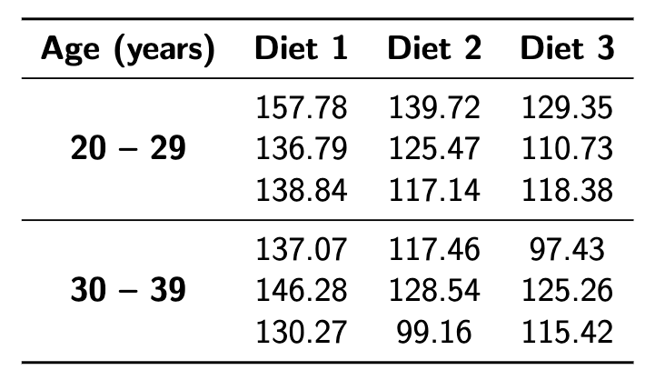

- What is the outcome?
- What are the two factors?
- What is the interaction term?

## Example

```r
library(tidyverse)
example <- tibble(birthweight = c(157.78, 136.79, 138.84, # age 20-29, diet 1
                                  139.72, 125.47, 117.14, # age 20-29, diet 2
                                  129.35, 110.73, 118.38, # age 20-29, diet 3
                                  137.07, 146.28, 130.27, # age 30-39, diet 1
                                  117.46, 128.54, 99.16, # age 30-39, diet 2
                                  97.43, 125.26, 115.42), # age 30-39, diet 3
                  diet = as.factor(c(1, 1, 1,
                                     2, 2, 2,
                                     3, 3, 3,
                                     1, 1, 1,
                                     2, 2, 2,
                                     3, 3, 3)),
                  age = as.factor(c(20, 20, 20,
                                    20, 20, 20,
                                    20, 20, 20,
                                    30, 30, 30,
                                    30, 30, 30,
                                    30, 30, 30)))
```

## Example

- Let’s find the ANOVA table,

```r
m <- aov(birthweight ~ diet + age + diet:age, data = example)
summary(m)
```

```
            Df Sum Sq Mean Sq F value  Pr(>F)
diet         2 2104.7  1052.3   7.555 0.00752 **
age          1  332.0   332.0   2.384 0.14855
diet:age     2   32.5    16.3   0.117 0.89083
Residuals   12 1671.5   139.3
---
Signif. codes:  0 '***' 0.001 '**' 0.01 '*' 0.05 '.' 0.1 ' ' 1
```

## Testing Interactions

- **Hypotheses**
  - $H_0:$ there is not an interaction between [factor A] and [factor B]
  - $H_1:$ there is an interaction between [factor A] and [factor B]
- **Test Statistic and *p*-Value**
  - $F_{\text{AB}}$ (pull from ANOVA table)
  - $p = P[F_{\text{df}_{\text{AB}}, \text{df}_{\text{E}}} \ge F_{\text{AB}}]$
- **Rejection Region**
  - Reject $H_0$ if $p<\alpha$.

## Example

- Let’s now test the interaction between age and diet. Test at the $\alpha=0.05$ level.
- Here’s the information we need:

```r
summary(m)
```

```
            Df Sum Sq Mean Sq F value  Pr(>F)
diet         2 2104.7  1052.3   7.555 0.00752 **
age          1  332.0   332.0   2.384 0.14855
diet:age     2   32.5    16.3   0.117 0.89083
Residuals   12 1671.5   139.3
---
Signif. codes:  0 '***' 0.001 '**' 0.01 '*' 0.05 '.' 0.1 ' ' 1
```

## Example

- **Hypotheses**
  - $H_0:$ there is not an interaction between age and diet
  - $H_1:$ there is an interaction between age and diet
- **Test Statistic**
  - $F_{\text{AB}} = 0.117$
  - $p = 0.891$
- **Rejection Region**
  - Reject $H_0$ if $p<\alpha$; $\alpha=0.05$.
- **Conclusion/Interpretation**
  - Fail to reject $H_0$. There is not sufficient evidence to suggest that the relationship between average birth weight and age depends on the mother’s diet.

## Testing Interactions

- What happens after testing for an interaction?
  - If significant (reject $H_0$), we can:
    - Construct a profile plot to visualize what’s going on and help explain the effect.
    - Examine posthoc testing to further examine the interaction.
  - If not significant (FTR $H_0$), we should remove the interaction term so that we can test and interpret the main effects.
- Remember that we cannot look at main effects (A and B alone) when the interaction is included in the model!

## Removing Interactions

- If the interaction term is not significant, it should be removed from the ANOVA table so that we can test and interpret the main effects.
- How to remove an interaction:
  1. Rewrite ANOVA table without interaction; do not change SS, df, and MS for the main effects and total.
  2. Update the error term: add the SS$_{\text{AB}}$ to SS$_{\text{E}}$ and df$_{\text{AB}}$ to df$_{\text{E}}$.
  3. Recalculate MS$_{\text{E}}$.
  4. Recalculate $F$ statistics for the main effects and perform appropriate hypothesis tests.
- In R, we just literally remove the interaction term.

```r
m <- aov(continuous_variable ~ factor_A + factor_B,
         data = dataset_name)
summary(m)
```

## Example

- Let’s now remove the interaction between diet and maternal age.

```r
#m <- aov(birthweight ~ diet + age + diet:age, data = example)
m <- aov(birthweight ~ diet + age, data = example)
summary(m)
```

```
            Df Sum Sq Mean Sq F value  Pr(>F)
diet         2   2105  1052.3   8.646 0.00359 **
age          1    332   332.0   2.728 0.12085
Residuals   14   1704   121.7
---
Signif. codes:  0 '***' 0.001 '**' 0.01 '*' 0.05 '.' 0.1 ' ' 1
```

## Testing Main Effects

- Now that we have removed the interaction term, we can test for main effects.
- **Hypotheses**
  - $H_0:$ there is not a main effect of [factor X]
  - $H_1:$ there not a main effect of [factor X]
- **Test Statistic and *p*-Value**
  - $F_{\text{X}}$ (pull from ANOVA table)
  - $p = P[F_{\text{df}_{\text{X}}, \text{df}_{\text{E}}} \ge F_{\text{X}}]$
- **Rejection Region**
  - Reject $H_0$ if $p<\alpha$.

## Testing Main Effects

- A note on hypotheses – we are writing them in sentence form here, however, we can write them mathematically.
- For Factor A with $a$ levels,
  - $H_0: \mu_1 = \mu_2 = ... = \mu_a$
  - $H_1:$ at least one is different
- For Factor B with $b$ levels,
  - $H_0: \mu_1 = \mu_2 = ... = \mu_b$
  - $H_1:$ at least one is different

## Example

- We now want to determine if there are main effects of age and diet. Test at the $\alpha=0.05$ level.
- The ANOVA table without the interaction term:

```r
summary(m)
```

```
            Df Sum Sq Mean Sq F value  Pr(>F)
diet         2   2105  1052.3   8.646 0.00359 **
age          1    332   332.0   2.728 0.12085
Residuals   14   1704   121.7
---
Signif. codes:  0 '***' 0.001 '**' 0.01 '*' 0.05 '.' 0.1 ' ' 1
```

## Example

- **Hypotheses**
  - $H_0:$ there is not a main effect of diet ($\mu_1 = \mu_2 = \mu_3$)
  - $H_1:$ there is a main effect of diet (at least one $\mu_i$ is different)
- **Test Statistic and *p*-Value**
  - $F_{\text{diet}} = 8.646$
  - $p = 0.004$
- **Rejection Region**
  - Reject $H_0$ if $p<\alpha$; $\alpha=0.05$.
- **Conclusion/Interpretation**
  - Reject $H_0$. There is sufficient evidence to suggest that at least one diet reults in a different birth weight.

## Example

- **Hypotheses**
  - $H_0:$ there is not a main effect of age ($\mu_1 = \mu_2$)
  - $H_1:$ there is a main effect of age ($\mu_1 \ne \mu_2$)
- **Test Statistic and *p*-Value**
  - $F_{\text{age}} = 2.728$
  - $p = 0.121$
- **Rejection Region**
  - Reject $H_0$ if $p<\alpha$; $\alpha=0.05$.
- **Conclusion/Interpretation**
  - Fail to reject $H_0$. There is not sufficient evidence to suggest that there is a difference in birth weights across the age groups.

## Introduction: Beyond the *F* Test

- In this lecture, we are discussing two-way ANOVA.
- So far, we have learned how to:
  - Create an ANOVA model with an interaction term
  - Test the interaction term
  - Create an ANOVA model without an interaction term
  - Test the main effects
- Now we will learn how to best communicate results, whether it’s the resulting interaction term or main effects.

## Profile Plots

- If we detect an interaction term, we must give meaning to it.
- An easy way to do this is to plot the treatment group means to visualize the interaction. This is called a profile plot.
  - *y*-axis: always the average outcome
  - *x*-axis: either factor A or B
    - if only one factor is ordinal, use it for the *x*-axis
    - if there are two ordinal or two nominal factors, select the factor with the largest number of levels for the *x*-axis
  - lines on the plot: the factor that was not selected for the *x*-axis
- Note that this is just a graph of the means – it’s valid to construct a profile plot even if the interaction is not sigificant.

## Example

- Let’s first find the treatment means for the birth weight data,

```r
means <- example %>%
  group_by(diet, age) %>%
  summarize(mean = mean(birthweight)) %>%
  ungroup()
head(means)
```

| diet | age | mean |
| --- | --- | --- |
| 1 | 20 | 144.4700 |
| 1 | 30 | 137.8733 |
| 2 | 20 | 127.4433 |
| 2 | 30 | 115.0533 |
| 3 | 20 | 119.4867 |
| 3 | 30 | 112.7033 |

## Example

- The average birth weight will go on our *y*-axis.
- Because only maternal age is ordinal, it will go on our *x*-axis.
- Thus, the lines will represent the diet
  - This means I want to restructure the dataset with the means to have a column for each of the diets

```r
A <- means %>% filter(diet == 1) %>% rename(d1 = mean) %>% select(-diet)
B <- means %>% filter(diet == 2) %>% rename(d2 = mean) %>% select(-diet)
C <- means %>% filter(diet == 3) %>% rename(d3 = mean) %>% select(-diet)
graph <- full_join(A, B, by = "age")
graph <- full_join(graph, C, by = "age")
```

## Example

```r
graph
```

| age | d1 | d2 | d3 |
| --- | --- | --- | --- |
| 20 | 144.4700 | 127.4433 | 119.4867 |
| 30 | 137.8733 | 115.0533 | 112.7033 |

## Example

- Building profile plots using `ggplot()` is a process.
  - First, include a `geom_line()` for each level of the factor creating the lines.

```r
graph %>%
  ggplot(aes(x = age, group = 1)) +
  geom_line(aes(y = d1), color = "pink") + # diet 1
  geom_line(aes(y = d2), color = "purple") + # diet 2
  geom_line(aes(y = d3), color = "blue") + # diet 3
  theme_bw()
```

## Example

- Building profile plots using `ggplot()` is a process.
  - First, include a `geom_line()` for each level of the factor creating the lines.

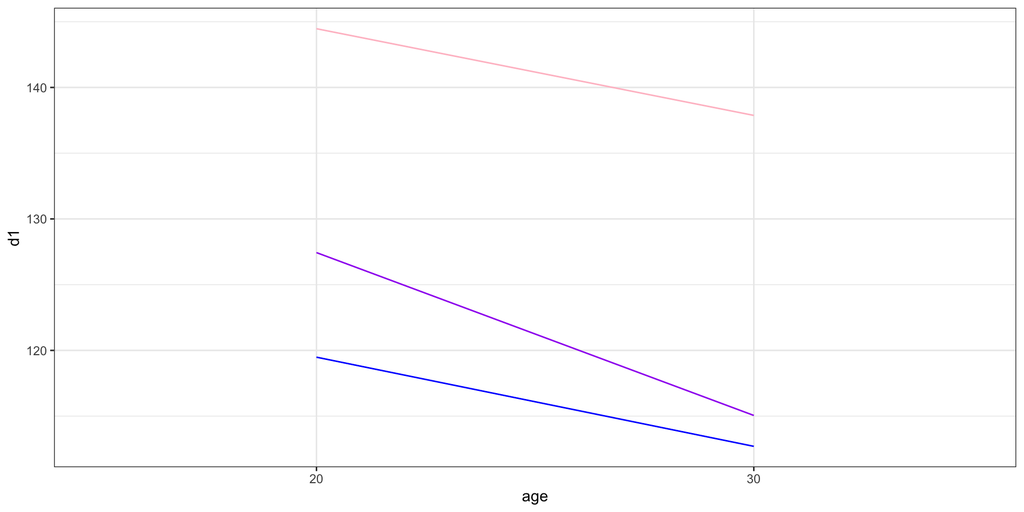

## Example

- Building profile plots using `ggplot()` is a process.
  - Then, add `geom_text()` to label each line (use the line colors to make sure everything is labeled properly).

```r
graph %>%
  ggplot(aes(x = age, group = 1)) +
  geom_line(aes(y = d1), color = "pink") + # diet 1
  geom_line(aes(y = d2), color = "purple") + # diet 2
  geom_line(aes(y = d3), color = "blue") + # diet 3
  geom_text(aes(x = "30" , y = 137, label = "Diet 1"), color = "pink")  + # diet 1
  geom_text(aes(x = "30" , y = 115, label = "Diet 2"), color = "purple")  + # diet 2
  geom_text(aes(x = "30" , y = 110, label = "Diet 3"), color = "blue")  + # diet 3
  theme_bw()
```

## Example

- Building profile plots using `ggplot()` is a process.
  - Then, add `geom_text()` to label each line (use the line colors to make sure everything is labeled properly).

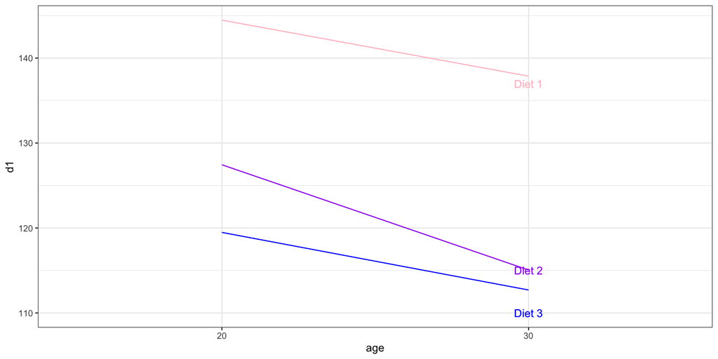

## Example

- Building profile plots using `ggplot()` is a process.
  - Then, clean up time: fix axis titles and change line colors to black*

```r
graph %>%
  ggplot(aes(x = age, group = 1)) +
  geom_line(aes(y = d1), color = "black") + # diet 1
  geom_line(aes(y = d2), color = "black") + # diet 2
  geom_line(aes(y = d3), color = "black") + # diet 3+
  geom_text(aes(x = "30" , y = 137, label = "Diet 1"), color = "black")  + # diet 1
  geom_text(aes(x = "30" , y = 115, label = "Diet 2"), color = "black")  + # diet 2
  geom_text(aes(x = "30" , y = 110, label = "Diet 3"), color = "black")  + # diet 3
  labs(x = "Maternal Age",
       y = "Average Birth Weight") +
  theme_bw()
```

## Example

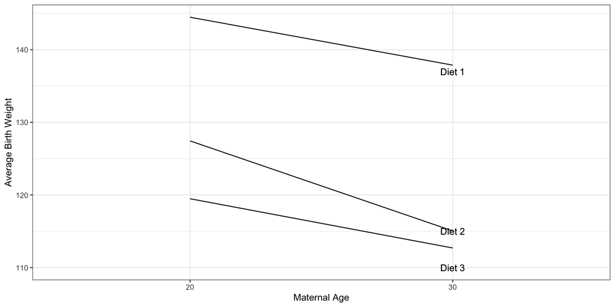

## Posthoc Tests

- We can also apply posthoc testing to two-way ANOVA.
  - If the interaction is significant, we can compare all treatment groups.
  - If the interaction is not significant, we can look at the main effects.
- For simplicity, we will only look at Tukey’s and Fisher’s.
- What is the difference between Tukey’s and Fisher’s?

## Example

- Let’s apply Tukey’s to the model with the interaction term.
  - **Important!!** Remember that we are only doing this for illustration purposes - we should not perform posthoc testing on something non-significant.

```r
m <- aov(birthweight ~ diet + age + diet:age, data = example)
TukeyHSD(m)$"diet:age"
```

```
                diff       lwr       upr      p adj
2:20-1:20 -17.026667 -49.39499 15.341659 0.51846118
3:20-1:20 -24.983333 -57.35166  7.384992 0.17257865
1:30-1:20  -6.596667 -38.96499 25.771659 0.98037295
2:30-1:20 -29.416667 -61.78499  2.951659 0.08309462
3:30-1:20 -31.766667 -64.13499  0.601659 0.05550164
3:20-2:20  -7.956667 -40.32499 24.411659 0.95688090
1:30-2:20  10.430000 -21.93833 42.798326 0.87931551
2:30-2:20 -12.390000 -44.75833 19.978326 0.78717713
3:30-2:20 -14.740000 -47.10833 17.628326 0.65386678
1:30-3:20  18.386667 -13.98166 50.754992 0.44210449
2:30-3:20  -4.433333 -36.80166 27.934992 0.99674874
3:30-3:20  -6.783333 -39.15166 25.584992 0.97786517
2:30-1:30 -22.820000 -55.18833  9.548326 0.24087234
3:30-1:30 -25.170000 -57.53833  7.198326 0.16754036
3:30-2:30  -2.350000 -34.71833 30.018326 0.99984711
```

## Example

- Let’s apply Tukey’s to the model without the interaction term.

```r
m <- aov(birthweight ~ diet + age, data = example)
TukeyHSD(m)$diet
```

```
          diff       lwr       upr      p adj
2-1 -19.923333 -36.59450 -3.252169 0.01902981
3-1 -25.076667 -41.74783 -8.405502 0.00397944
3-2  -5.153333 -21.82450 11.517831 0.70372399
```

- Which diets are significantly different? Use $\alpha=0.05$.

## Wrap Up

- We did not explicitly discuss assumptions, but they are the same as in one-way ANOVA.
- From here, ANOVA can be used to specify any model.
  - We stopped with two-way interactions, but you could have three-way interactions, four-way interactions, etc.
  - As you can see, interactions quickly complicate the interpretation, so I try to stay away from anything higher than a two-way interaction.
- Our next module is regression analysis, which is the *same* as ANOVA, but represents the results differently.
  - We can quantify the relationship between two variables using regression.